# 0. 앙상블 학습(Ensemble learning)

여러 분류기법과 회귀기법들이 합쳐져 예측성능을 높이는 학습.  
정밀도가 낮은 여러개의 모형을 생성하고, 이 모형들의 예측을 결합해 정밀도가 높은 예측을 도출한다.  
강력한 하나의 모델을 사용하기보단, 여러개의 약한 모델을 조합하여 더 정확한 예측을 한다.  
딥러닝을 쓸 만큼 자료의 크기가 충분하지 않을 때, 딥러닝만큼의 성능을 갖는 머신러닝 기법이다.

### Voting (투표분류기법)

: 앙상블 학습의 기본이 되는 기법. 앙상블에 이용되는 분류 기법들이 개념적으로 독립적일 때 효과가 높게 나타난다.

- Hard Voting  
  : 2개 이상의 분류기법들을 동일한 학습데이터에 각각 적합시킨 후, 분류기법별로 새로운 자료에 대한 클래스를 예측한다. 예측된 클래스 중 빈도가 가장 높은 클래스를 이 새로운 자료의 최종 클래스로 할당한다.
- Soft Voting  
  : 각 분류기법이 특정 클래스에 속할 확률을 제공하고, 그 클래스에 속할 평균 확률을 계산한다. 평균 확률이 가장 큰 클래스를 해당 관측치의 클래스로 할당한다.

# 1. Bagging

: 학습데이터를 with replace로 붓스트랩하여 각각의 모델을 학습시켜 결과를 합친다.

- Bootstrap  
  원래의 학습데이터의 크기가 n개라면, 이 학습데이터에서 임의로 n개의 표본을 복원추출하여 포본을 뽑는다. 이러한 n개의 표본으로 이루어진 데이터셋을 M개 생성한다.
- 학습  
  각 모델을 M개 데이터셋에 모두 적용하여, 각 모델의 예측 결과를 voting으로 집계한다.

$ \star$ oob(out-of-bag) 데이터의 활용  
Bagging에서는 복원 붓스트랩의 특성상 학습데이터의 일부가 반복적으로 뽑힐 수 있기에 붓스트랩 학습데이터에 포함되지 않은 학습데이터(=out-of-bag) 일부가 존재할 수 밖에 없다. oob를 검증데이터로 이용할 수 있다는 점 또한 bagging의 장점이다.

*참고  
without replace로 학습데이터를 붓스트랩하는 것은 'pasting'이라고 부른다

# ex) Random Forest

: 의사결정나무의 bagging버전

### Random Forest 분석절차

1. 크기가 n이고 d개의 특성변수를 가진 원래의 학습데이터에서 붓스트랩 표본을 뽑아 새로운 학습데이터 제작
2. 이 새로운 학습데이터를 이용해 의사결정나무의 노드마다 임의로 k(k<d)개의 특성변수를 뽑아 의사결정나무를 완성한다  
   (이때 k는 일반적으로 $k=\sqrt{d}$로 선택한다)
3. 1,2번 절차를 M번 반복한다  
   목적이 "분류"이면 새로운 관측치의 특성변수를 위 M개의 분류나무에 적용하여 voting으로 예측한다.  
   목적이 "회귀"이면 M개의 목표변수 y 예측치의 평균을 최종예측치로 한다.

$\star$ Random Forest에서 특성변수를 임의추출하는 이유  
: M개의 의사결정나무 간의 상관관계를 최소화하기 위함.  
ex) 만약 변별력이 매우 뛰어난 특성변수가 존재할 때, M개의 의사결정나무는 거의 다 이 변수를 선택하여 결과적으로 의사결정나무 간의 상관관계가 높아지게 된다. 모델간의 유사성이 높으면 정밀도가 높다는 앙상블 기법의 장점이 사라진다.

$\star$ 모든 Random Forest는 학습데이터와 특성변수를 랜덤하게 선택(확률화, randomness)하기 때문에 과대적합의 가능성이 낮다. 따라서 일반적인 의사결정나무와 달리 가지치기(prune)가 필요하지 않다.

$\star$ k는 일반적으로 $\sqrt{d}$로 선택하기에, Random Forest에서 조절해주어야 할 초모수는 M이다.  
M이 클수록 대수의 법칙에 의해 Random Forest의 성능이 좋아지므로, 컴퓨터의 성능이 가능한 한 큰 M을 선택하는 것이 좋다.

### Random Forest모형 실습

iris데이터에 적용한 예시 (데이터 설명은 생략)

```python
#데이터 불러오기
import seaborn as sns
iris=sns.load_dataset('iris')
X=iris.drop('species', axis=1)
y=iris['species']

#문자열인 목적변수(species)를 라벨인코딩
from sklearn.preprocessing import LabelEncoder
classle=LabelEncoder()
y=classle.fit_transform(iris['species'].values)

#시험데이터, 학습데이터 분리
from sklearn.model_selection import train_test_split
X_train, X_test, y_train, y_test=train_test_split(X,y,test_size=0.3, random_state=1, stratify=y)
```

```python
from sklearn.ensemble import BaggingClassifier
from sklearn.tree import DecisionTreeClassifier
bag_cl=BaggingClassifier(DecisionTreeClassifier(), n_estimators=500,
                         max_samples=100, bootstrap=True, oob_score=True)
bag_cl.fit(X_train, y_train)   #학습데이터 적합
y_pred=bag_cl.predict(X_test)  #test데이터에 대해 학습된 모델의 y예측치

#accuracy성능 출력
from sklearn.metrics import accuracy_score
print(f"test data accuracy: {accuracy_score(y_test, y_pred): .3}")
print(f"Out-of-bag score estimate: {bag_cl.oob_score_:.3}")
```

```
test data accuracy:  0.978
Out-of-bag score estimate: 0.952
```

500개의 의사결정나무를 결합하여(n_estimators=500) Bagging앙상블 모델을 구축.  
붓스트랩 표본의 크기를 100으로 지정(max_sample=100)  
복원으로 표본을 붓스트랩한다.(bootstrap=True / False이면 pasting이 실행됨)  
out-of-bag(oob)자료를 이용해 검증데이터의 정밀도를 구하기 위해 oob_score=True로 지정하여 oob자료를 활용할 수 있게 한다.

DecisionTree를 Bagging ensemble한 모델은 RandomForest클래스로도 구현가능하다.

```python
from sklearn.ensemble import RandomForestClassifier
forest=RandomForestClassifier(n_estimators=500, criterion='gini',
                              max_samples=100, random_state=1, oob_score=True)
forest.fit(X_train, y_train)      # train데이터를 학습
y_test_pred=forest.predict(X_test)  # test데이터에 대해 학습된 모델의 y예측치

#accuracy성능 출력
print(f"test data accuracy: {accuracy_score(y_test, y_test_pred): .3}")
print(f"Out-of-bag score estimate: {forest.oob_score_:.3}")
```

```
test data accuracy:  0.978
Out-of-bag score estimate: 0.933
```

분류의 목적이므로 RandomForestClassifier 클래스를 호출하여 실행 (회귀가 목적이면 RandomForestRegressor를 실행)  
앞선 BaggingClassifier에서의 파라미터와 동일하게 지정해주었다.

RandomForestClassifier의 주요 파라미터들은 아래와 같다

- n_estimators : 트리의 개수 결정
- criterion : 가지 분할 시 기준이 되는 손실함수
- max_depth : 트리의 최대 깊이
- max_leaf_nodes : 단말 노드 수의 최대치
- min_samples_split : 내부 노드를 분할하는데 필요한 최소 샘플 수

# 2. Boosting

: weak learner들을 여러 개 결합하여 예측 및 분류 성능을 높이는 알고리즘.

$\star$ weak learner란?  
무작위로 선택하는 것보단 성능이 우수하지만(즉, 평균모형보다는 성능이 우수하지만) 아주 확실하고 정확하지는 않은 모델.

Boosting은 weak learner들을 연속적으로 배치하며, 바로 직전 weak learner의 error를 반영하여 이를 맞출 수 있도록 현재 weak learner를 학습시킨다. 이러한 방식으로 여러개의 weak learner들을 순서대로 결합하여 strong learner를 만들어낸다.

$\star$ Bagging과 Boosting의 차이  
Bagging은 M개의 독립적인 모형을 서로 다른 M개의 bootstrap 학습데이터에 적용해 각 예측치의 평균을 산출한다.  
반면 Boosting은 한 개의 학습데이터에 순차적으로 weak learner를 적용하여 모형을 구성한다.

# ex1) Adaboost (Adaptive Boost)

: 이전 weak learner에서 올바르게 분류한 학습데이터의 가중치는 줄이고, 오분류된 학습데이터의 가중치를 높여서 새로운 weak learner가 학습하게 한다. 이 과정은 M회 반복하여 M개의 분류모형을 선형결합해 최종 모형을 결정한다.

즉, 이전 모형이 제대로 예측하지 못한 데이터에 더 집중하여 이들을 더 잘 예측하도록 약점을 보완하는 모형을 만들게 된다.

### Adaboost의 기본 형태

m번째 단계의 데이터에 적합시킨 weak learner 트리모형을 $f_{m}$라 한다.  
해당 단계 $f_{m}$의 정보량은 $as_{m}=\frac{1}{2}ln(\frac{1-e_{m}}{e_{m}})$이다.  
($e_{m}$은 총오차를 의미하며, 해당 단계에서 전체 데이터 중 $f_{m}$이 잘못 분류한 표본의 비율이다.)

- 잘못 분류된 경우($y_{i}\cdot f_{m}<0$)이면, $w_{i}^{m+1}=exp(as_{m})$
- 잘 분류된 경우($y_{i}\cdot f_{m}>0$)이면, $w_{i}^{m+1}=exp(-as_{m})$

로 가중치를 조정하고 이 가중치를 반영하여 다음 m+1단계의 표본을 복원추출한다.

각 단계마다  
[ 해당 단계에서 주어진 표본에 모형 $f_{m}$적합 ] $\to$ [ 총오자 $e_{m}$과 정보량 $as_{m}$계산 ] $\to$ [ 이를 바탕으로 표본에 새 가중치를 매김 ] $\to$ [ 가중치를 반영하여 다시 n개의 표본을 추출 ]  
을 반복한다

이를 M회 반복했을 때 예측치는 $\widehat{h}=sign(\sum_{i=1}^{M}as_{i}\cdot f_{i})$ 이다.

### Adaboost에서 사용되는 손실함수

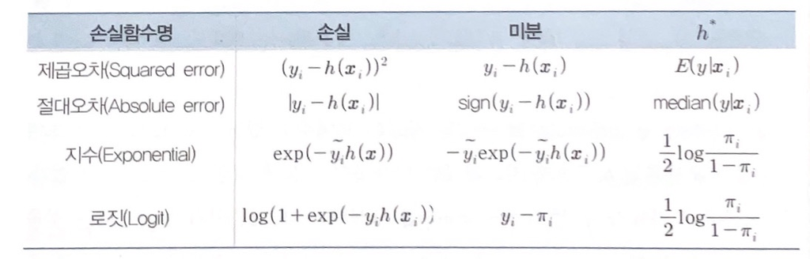

```python
from IPython.display import Image
image_path = 'C:/Users/MijinJ/OneDrive - 경북대학교/바탕 화면/jupyter사진/AdaBoost.jpg'
Image(filename=image_path, width=700)
```

### 일반적인 지수(Exponential) 손실함수

$y_{i}=\left\{-1,1 \right\}$, $h$는 추정치라고 할 때, 지수 손실함수에 대한 최적의 추정치 $h^{*}$를 구하려고 함
손실함수는 다음과 같이 정의된다 $$l=exp(-yh)$$
손실함수를 미분하면, $$\frac{\partial L}{\partial h}=-yexp(-yh)$$
이때 추정치 h는 $\mathbf{x}_{i}$의 함수이므로

$$E(-y \textit{exp}(-yh)|\mathbf{x}_{i})=-\textit{exp}(-h)P(y=1|\mathbf{x}_{i})+\textit{exp}(h)P(y=-1|\mathbf{x}_{i})=0$$

을 만족하는 h의 최적해는 $$h^{*}=\frac{1}{2}log\frac{P(y=1|\mathbf{x}_{i})}{P(y=-1|\mathbf{x}_{i})}$$ 이다.

$\therefore $ $P(y=1|\mathbf{x}_{i})>0.5$이면 $h^{*}(\mathbf{x}_{i})>0$이 된다. 이때 $\mathbf{x}_{i}$에 대응되는 $y_{i}$의 범주는 1로 예측한다.

### Adaboost에서의 지수 손실함수

손실함수는 다음과 같이 정의된다. $$\sum_{i=1}^{n}exp(y_{i}(h_{m-1}(\mathbf{x}_{i})+\beta(\mathbf{x}_{i})))$$ $$=\sum_{i=1}^{n}exp(-y_{i}h_{m-1}(\mathbf{x}_{i}))\cdot exp(-y_{i}\beta f(\mathbf{x}_{i}))$$ 이 중 앞부분인 $exp(-y_{i}h_{m-1}(\mathbf{x}_{i}))$를 $w_{i}^{(m)}$라 하자.

이때 $h_{m-1}(\mathbf{x}_{i})$는 (m-1)번쨰 단계에서 계산된 $y_{i}$의 예측치이다.  
즉, $h_{m-1}=sign(\sum_{i=1}^{m-1}as_{i}\cdot f_{i})$이다.  
$h_{m-1}(\mathbf{x}_{i})$가 $y_{i}$의 범주를 잘못 예측하면 $y_{i}h_{m-1}(\mathbf{x}_{i})<0$이 되므로 $w_{i}^{(m)}$이 커진다.  
따라서 이러한 원리로 전단계인 (m-1)단계에서 예측오차가 큰 데이터에 큰 가중치를 부여한다.  
이를 바탕으로 m단계에선 큰 가중치를 가진 데이터를 제대로 분류하도록 하는 $\beta$와 $f$를 추정한다.

손실함수로 돌아와, 해당 단계의 분류기가 $y_{i}$를 제대로 예측할 때와 아닐때로 항을 나누어보자 $$ =\sum_{y_{i}=f(\mathbf{x}_{i})}w_{i}^{(m)}e^{-\beta}+\sum_{y_{i}\neq f(\mathbf{x}_{i})}w_{i}^{(m)}e^{\beta}$$ $$=\sum_{i=1}^{n}w_{i}^{(m)}e^{-\beta}(1-I(y_{i}\neq f(\mathbf{x}_{i}))) + \sum_{i=1}^{n}w_{i}^{(m)}e^{\beta}I(y_{i}\neq f(\mathbf{x}_{i}))$$ $$=(e^{\beta}-e^{-\beta})\sum_{i=1}^{n}w_{i}^{(m)}I(y_{i}\neq f(\mathbf{x}_{i}))+e^{-\beta}\sum_{i=1}^{n}w_{i}^{(m)}$$ 즉, 손실함수의 최소화는 $\sum_{i=1}^{n}w_{i}^{(m)}I(y_{i}\neq f(\mathbf{x}_{i}))$의 최소화를 의미한다.

위 식을 최소화하는 weak learner $f(\mathbf{x}_{i})$는 불순도 지수를 이용해 구한다.  
위 식을 최소화하는 $\beta_{m}=\frac{1}{2}log\frac{1-e_{m}}{e_{m}}=as_{m}$  
위 식을 최소화하는 $e_{m}=\frac{\sum_{i=1}^{n}w_{i}^{(m)}I(y_{i}\neq f(\mathbf{x}_{i}))}{\sum_{i=1}^{n}w_{i}^{(m)}}$

### Adaboost모형 실습

iris데이터에 Adaboost를 적용한다.  
이 실습에서는 깊이가 2인 분류나무를 weak learner로 삼아, M=500개의 weak learner로 구성하였다.

```python
from sklearn.ensemble import AdaBoostClassifier
ada_t=AdaBoostClassifier(DecisionTreeClassifier(max_depth=2), n_estimators=500, random_state=1)
ada_t.fit(X_train, y_train)
y_train_pred=ada_t.predict(X_train)
y_test_pred=ada_t.predict(X_test)

from sklearn.metrics import accuracy_score
ada_train=accuracy_score(y_train, y_train_pred)
ada_test=accuracy_score(y_test, y_test_pred)

print("Adaboost train/test accuracy %0.3f/%0.3f" %(ada_train, ada_test))
```

```
Adaboost train/test accuracy 1.000/0.978
```

weak learner로 낮은 깊이의 분류나무를 적용하였음에도 높은 정밀도.

# ex2) GBM (Gradient Boosting Method)

: 기울기 부스팅. 각 단계의 weak learner는 이전 weak learner의 예측치와 참값의 잔여오차(residual error)를 학습한다.

$\star$ 의사결정나무 복습
$$b(\mathbf{x},\gamma)=\sum_{j=1}^{J}\gamma_{j}I(\mathbf{x}\in R_{j})$$
$J$: 총 노드 수
$\gamma_{i}$ : j번째 노드에 속했을 때 $y_{i}$의 추정치
$R_{j}$ : 노드 $\gamma_{j}$에 의해 만들어진 영역
회귀나무면 $R_{j}$ 내 $y_{i}$들의 평균을, 분류나무면 $R_{j}$ 내 $y_{i}$의 최빈값을 $\gamma_{j}$의 추정치로 사용한다
$\gamma_{j}$와 $R_{j}$가 결정해야 할 모수이다

GBM의 초모수는 총 추가모형의 수(M)와 의사결정나무의 총 영역수(J)이다.  
일반적으로 J는 $4\leq J \leq8$ 정도의 값으로 설정한다

### GBM 알고리즘

1. $\sum_{i=1}^{n}l(y_{i},\gamma)$를 최소화하는 초기치 $f_{0}(\mathbf{x}_{i})=\gamma$ 계산
2. m=1부터 M까지 다음을 반복
   (a) $g_{im}=[\frac{\partial l(y_{i},f(\mathbf{x}_{i}))}{\partial f(\mathbf{x}_{i})}]_{f=f_{m-1}}$
   (b) 의사결정나무의 일반적인 절차를 따라 결정된 J개의 배반인 영역 $R_{jm}$을 구한 뒤, $$\sum_{i=1}^{n}(-g_{im}-\sum_{j=1}^{J}\gamma_{jm}I(\mathbf{x}_{i}\in R_{jm}))^{2}$$을 최소화하는 $\widehat{\gamma}_{jm}$을 구한다.
   (c) $\sum_{i=1}^{n}l(y_{i},f_{m-1}(\mathbf{x}_{i})+\eta_{m}\sum_{j=1}^{J}\widehat{\gamma}_{jm}I(\mathbf{x}_{i}\in R_{jm}))$을 최소화하는 $\eta_{m}$을 구한다
   (d) $f_{m}(\mathbf{x}_{i})=f_{m-1}(\mathbf{x}_{i})+\widehat{\eta}_{m}\sum_{j=1}^{J}\widehat{\gamma}_{jm}I(\mathbf{x}_{i}\in R_{jm})$으로 업데이트한다
3. $\widehat{f}(\mathbf{x}_{i})=f_{M}(\mathbf{x}_{i})$이다

### GBM 학습과정의 직관적인 이해

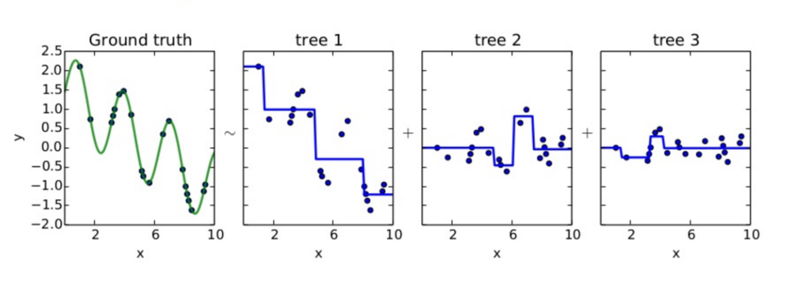

```python
from IPython.display import Image
image_path = 'C:/Users/MijinJ/OneDrive - 경북대학교/바탕 화면/jupyter사진/GBM2.png'
Image(filename=image_path, width=700)
#[이미지 출처] https://beavekim23.tistory.com/3
```

Ground truth의 그림이 실제 데이터의 y참값이다.  
tree1 그림의 파란색 선이 첫번째 weak learner로 예측한 결과이고, 각 점은 실제 데이터이다.  
tree2 그림의 데이터 포인트는 앞서 tree1그림의 데이터 참값과 예측치(파란색 선) 간의 잔차이다.  
두번째 weak learner는 첫번째 weak learner의 예측 결과로 나온 잔차를 예측하도록 학습한다.  
tree3 그림의 데이터 포인트는 tree2그림의 데이터 포인트와 예측치(파란색 선) 간의 잔차이다.  
세번째 weak learner는 첫번째와 두번째 weak learner의 예측결과로 나온 잔차를 예측한다.  
이러한 방법을 반복하면 잔차를 계속 줄어들고, 학습 데이터를 잘 설명하는 strong learner를 만들 수 있다.

GBM의 손실함수가 MSE일 때 negative gradient가 잔차이기 때문에 위의 그림처럼 작동한다.  
어떤 손실함수를 사용하는지에 따라 negative gradient는 조금씩 달라진다.  
하지만 gradient를 정의하는 방법만 달라질 뿐, 기본적인 학습 원리는 위와 동일하다.

> 즉, 앞선 모델의 negative gradient를 현재 모델이 학습함으로써 순차적으로 모델을 구성해나가고, 그 결과 학습데이터에 잘 적합된 강한 모델이 만들어진다.

다음은 GBM에서 사용되는 주요 손실함수와 손실함수에 따른 negative gradient를 정리한 표이다

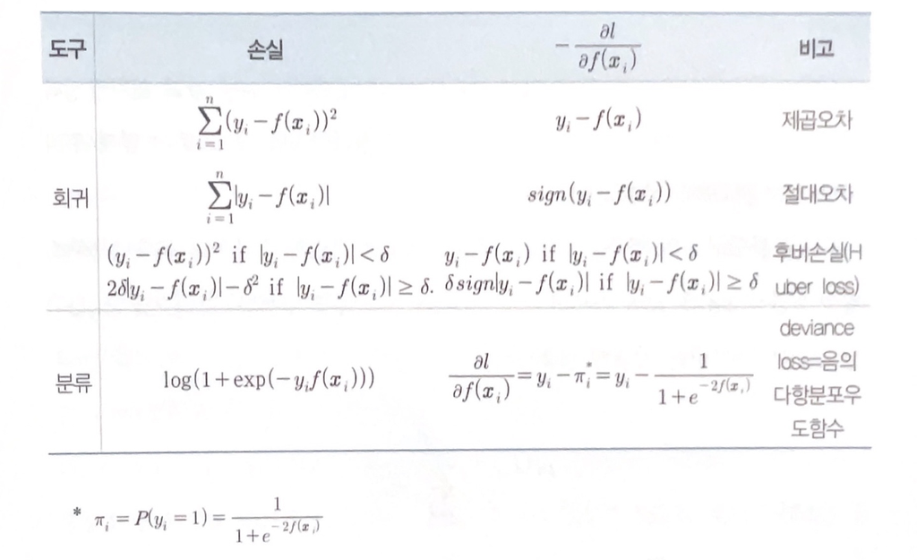

```python
from IPython.display import Image
image_path = 'C:/Users/MijinJ/OneDrive - 경북대학교/바탕 화면/jupyter사진/GBM.jpg'
Image(filename=image_path, width=700)
```

### 분류가 목적일 때의 GBM

클래스의 수가 K개 일 때, 하나-나머지(one-versus-rest)기법에 따라  
$f_{1}$ : 첫번째 클래스 대 나머지 클래스  
$f_{2}$ : 두번째 클래스 대 나머지 클래스  
$f_{3}$ : 세번째 클래스 대 나머지 클래스  
등등으로 차례로 적용한 분류기 $f_{1}, f_{2}, ..., f_{K}$를 차례로 산출한다.

$f_{k}$를 산출하는 방법은,  
i번째 데이터가 k번째 클래스에 속하면 $y_{i}=1$, 아니면 $y_{i}=0$ 값을 할당한다. 그 이후는 앞선 GBM학습과정과 동일하다.

분류기 $f_{1}, f_{2}, ..., f_{K}$가 만들어진뒤 예측치를 출력하는 방법은,  
해당 표본의 특성변수를 K개의 함수에 모두 대입하여 이 중 가장 큰 값을 갖는 클래스를 이 특성함수의 클래스로 할당한다.

### GBM모형 실습

: House데이터에 적용.

```python
import pandas as pd
#데이터 불러오기
house=pd.read_csv('https://raw.githubusercontent.com/rasbt/'
                 'python-machine-learning-book-2nd-edition'
                 '/master/code/ch10/housing.data.txt',header=None, sep='\s+')
#변수명 지정
house.columns=['CRIM', 'ZN', 'INDUS', 'CHAS', 'NOX', 'RM', 'AGE', 'DIS', 'RAD', 'TAX', 'PTRATIO', 'B', 'LSTAT', 'MEDV']
house.head()
```

|  | CRIM | ZN | INDUS | CHAS | NOX | RM | AGE | DIS | RAD | TAX | PTRATIO | B | LSTAT | MEDV |
| --- | --- | --- | --- | --- | --- | --- | --- | --- | --- | --- | --- | --- | --- | --- |
| 0 | 0.00632 | 18.0 | 2.31 | 0 | 0.538 | 6.575 | 65.2 | 4.0900 | 1 | 296.0 | 15.3 | 396.90 | 4.98 | 24.0 |
| 1 | 0.02731 | 0.0 | 7.07 | 0 | 0.469 | 6.421 | 78.9 | 4.9671 | 2 | 242.0 | 17.8 | 396.90 | 9.14 | 21.6 |
| 2 | 0.02729 | 0.0 | 7.07 | 0 | 0.469 | 7.185 | 61.1 | 4.9671 | 2 | 242.0 | 17.8 | 392.83 | 4.03 | 34.7 |
| 3 | 0.03237 | 0.0 | 2.18 | 0 | 0.458 | 6.998 | 45.8 | 6.0622 | 3 | 222.0 | 18.7 | 394.63 | 2.94 | 33.4 |
| 4 | 0.06905 | 0.0 | 2.18 | 0 | 0.458 | 7.147 | 54.2 | 6.0622 | 3 | 222.0 | 18.7 | 396.90 | 5.33 | 36.2 |

```python
print(house.info())      #총 표본수(506개), 총 변수수(14개), 변수별 결측여부, 변수의 자료타입
```

```
<class 'pandas.core.frame.DataFrame'>
RangeIndex: 506 entries, 0 to 505
Data columns (total 14 columns):
 #   Column   Non-Null Count  Dtype
---  ------   --------------  -----
 0   CRIM     506 non-null    float64
 1   ZN       506 non-null    float64
 2   INDUS    506 non-null    float64
 3   CHAS     506 non-null    int64
 4   NOX      506 non-null    float64
 5   RM       506 non-null    float64
 6   AGE      506 non-null    float64
 7   DIS      506 non-null    float64
 8   RAD      506 non-null    int64
 9   TAX      506 non-null    float64
 10  PTRATIO  506 non-null    float64
 11  B        506 non-null    float64
 12  LSTAT    506 non-null    float64
 13  MEDV     506 non-null    float64
dtypes: float64(12), int64(2)
memory usage: 55.5 KB
None
```

```python
# 13개의 특성변수, 목적변수는 주택가격인 'MEDV'
from sklearn.tree import DecisionTreeRegressor
X=house.iloc[:,:-1].values
y=house['MEDV'].values

#학습데이터와 시험데이터 분리
import numpy as np
from sklearn.model_selection import train_test_split
from sklearn.metrics import mean_squared_error
X_train, X_test, y_train, y_test = train_test_split(X,y,test_size=0.5, random_state=1)
```

```python
from sklearn.ensemble import GradientBoostingRegressor
gbrg=GradientBoostingRegressor(n_estimators=120, max_depth=3)  #반복횟수 120을 잠정적으로 설정, 회귀나무의 깊이 3
gbrg.fit(X_train, y_train)                                     #일차적으로 학습데이터 학습
errors=[mean_squared_error(y_test, y_pred) for y_pred in gbrg.staged_predict(X_test)]
bst_n_estimators=np.argmin(errors)                             #가장 낮은 MSE를 보이는 M을 결정한다.
bst_n_estimators
```

```
108
```

초기 모형을 반복횟수 120을 잠정적으로 설정하고 일차적으로 학습한다.  
적절한 트리 수 M을 결정하기 위해 staged_predict() 메서드를 활용한다. 실행 결과 최적의 트리수는 108개라는 결과이다.

- n_estimators : 트리 수(반복 횟수 M)
- max_depth : 트리의 깊이(노드 수)
- learning_rate : 학습률. 낮을수록 필요한 트리가 많아져 계산량이 많아지나 성능은 좋아진다.

staged_predict()에서 구한 최적의 트리수로 다시 모델을 학습한다.

```python
gbrg_best=GradientBoostingRegressor(max_depth=3, n_estimators=bst_n_estimators)
gbrg_best.fit(X_train, y_train)

y_train_pred=gbrg_best.predict(X_train)
y_test_pred=gbrg_best.predict(X_test)
from sklearn.metrics import r2_score
print('R**2 train : %0.3f, test: %0.3f' %(r2_score(y_train, y_train_pred), r2_score(y_test, y_test_pred)))
```

```
R**2 train : 0.999, test: 0.952
```

### GBM의 해석

덧셈 방식의 부스팅에 의한 의사결정나무는 수많은 의사결정나무로 구성되어 있어 별도의 해석 도구가 필요하다. 특성변수가 목적변수를 설명하는 지표를 사용한다.

- 1. 중요도(importance)
     회귀 : 매 회귀나무마다 2개의 영역으로 나눈 결과로 줄어든 SSE를 확인할 수 있다. GBM은 M개의 회귀나무가 있으므로 줄어든 SSE의 평균을 구할 수 있다. $$각 특성변수의 중요도 = \frac{해당 특성변수로 줄어든 SSE 평균}{줄어든 전체 SSE 평균}$$ 분류 : SSE 대신 Information Gain을 이용해 상대중요도 계산
- 1. 부분의존플롯(partial dependence plot)  
     선형회귀모형에서의 회귀계수 $\beta$와 같은 역할. 다른 변수의 효과를 제거하였을 때 해당 변수가 한 단위 증가하면 목적변수가 얼만큼 증가하는지를 의미

위 gbrg_best의 학습 결과 13개의 특성변수 각각에 대한 변수중요도를 feature*importances* 메서드로 확인할 수 있다

```python
print(gbrg_best.feature_importances_)
```

```
[2.44251924e-02 7.57060174e-05 5.58955090e-03 6.21104369e-04
 1.63561467e-02 2.66327093e-01 1.04740376e-02 1.01571770e-01
 4.78183272e-03 1.55484993e-02 2.48800653e-02 1.57393365e-02
 5.13609665e-01]
```

# ex3) XGBoost (Extreme Gradient Boosting)

### 특징

- GBM과 동일한 알고리즘을 사용하지만, 계산속도가 GBM보다 훨씬 빠르다.
- GBM과 달리 과대적합을 방지하기 위한 정규화가 추가되었다.

  > (GBM은 과대적합이 자주 일어나는데 내부적으로 모수에 대해 규제화를 하는 기능이 없어 교차검증 등의 기능을 부가적으로 이용해 모수를 조절해야 한다. XGBoost는 규제화의 기능을 내부적으로 포함하고 있다.)
- 자료의 크기가 딥러닝을 사용할 만큼 크지 못하거나, 정형화된 자료에서는 가장 강력한 머신러닝 기법이다.
- 결측치를 모두 0으로 처리하여, 해당 값을 결측치로 학습하게 하는 기능이 있다. (결측치를 0이 아닌 다른 값으로 지정하는 것도 가능)
- 특성변수를 임의로 일부만 뽑아 사용할 수도 있다.